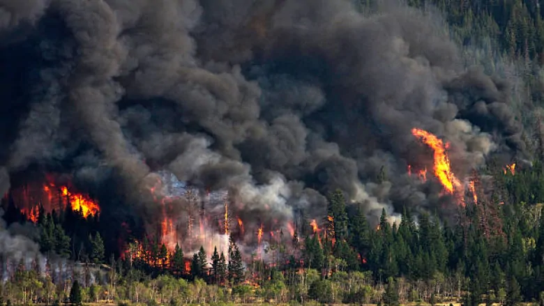

# Forest Fires In Brazil - A Time Series Data Analysis

By Arun James and Jonathan Cyriac

# Introduction

Brazil is the largest country in Latin America with 3.2 million square miles of land and populated by approximately 208 million people. About 60% of this vast and diverse country holds part of the Amazon Rainforest. The Amazon is the world's largest tropical forest and of the part in Brazil, comprises abotu 1/3 of the world's remaining rainforests. It is home to over 56,000 identified plants, 1700 bird species, 695 unique amphibians, 578 mammals and 651 reptiles species. The Amazon Basin also possess an assortment of vegetation like rainforests, seasonal forests, deciduous forests, flooded forests and savannas.

Sadly, a mix of environmental and human factors have contributed to a massive amount of deforestation. It has torrential rain and almost never burns on its own, but when it burns, the blazes burn for weeks. It grows so intense that smoke is sent all the way to São Paulo, Brazil's largest city.

Forest fires are a serious problem for the preservation of the tropical forests. In order to maintain the environment, protect the species that already inhabit the Amazon, and preserve the area for future generations to experience and enjoy. We aim to understand the frequency and patterns of forest fires in a time series that can help to take action to prevent them.

- The Forest Fire dataset can be found at Kaggle, at the following Link: https://www.kaggle.com/gustavomodelli/forest-fires-in-brazil
- The Rainfall dataset can be found on Kaggle: https://www.kaggle.com/fabiopotsch/precipitation-in-brazil
- The Agriculture dataset can be found on Data World: https://data.world/hdx/39056c79-3267-42d3-98cd-595ac6d91578

## Importing Libraries

```python
import numpy as np
import pandas as pd
import seaborn as sns
import matplotlib.pyplot as plt
from matplotlib.pyplot import MaxNLocator, FuncFormatter
from sklearn.linear_model import LinearRegression
from sklearn.preprocessing import PolynomialFeatures
from sklearn import datasets, linear_model, model_selection
```

## Data Scraping

Scrapes the Excel files to extract information on forest fires in Brazil, rainfall history and with agriculture statistics related to the area.

```python
data = pd.read_csv("data/amazon.csv", encoding="ISO-8859-1")
data.head()
```

|  | year | state | month | number | date |
| --- | --- | --- | --- | --- | --- |
| 0 | 1998 | Acre | Janeiro | 0.0 | 1998-01-01 |
| 1 | 1999 | Acre | Janeiro | 0.0 | 1999-01-01 |
| 2 | 2000 | Acre | Janeiro | 0.0 | 2000-01-01 |
| 3 | 2001 | Acre | Janeiro | 0.0 | 2001-01-01 |
| 4 | 2002 | Acre | Janeiro | 0.0 | 2002-01-01 |

```python
rainfall_data = pd.read_csv("data/precipitation.csv", encoding="ISO-8859-1")
rainfall_data.head()
```

|  | state | date | precipitation |
| --- | --- | --- | --- |
| 0 | BA | 31/01/1998 | 63.6 |
| 1 | BA | 28/02/1998 | 55.6 |
| 2 | BA | 31/03/1998 | 117.2 |
| 3 | BA | 30/04/1998 | 206.0 |
| 4 | BA | 31/05/1998 | 250.9 |

```python
agriculture_data = pd.read_csv("data/agriculture-rural-development-indicators.csv", encoding="ISO-8859-1")
agriculture_data.head()
```

|  | Country Name | Country ISO3 | Year | Indicator Name | Indicator Code | Value |
| --- | --- | --- | --- | --- | --- | --- |
| 0 | Brazil | BRA | 2006 | Agricultural machinery, tractors | AG.AGR.TRAC.NO | 788053.0 |
| 1 | Brazil | BRA | 2005 | Agricultural machinery, tractors | AG.AGR.TRAC.NO | 789622.0 |
| 2 | Brazil | BRA | 2004 | Agricultural machinery, tractors | AG.AGR.TRAC.NO | 791191.0 |
| 3 | Brazil | BRA | 2003 | Agricultural machinery, tractors | AG.AGR.TRAC.NO | 792760.0 |
| 4 | Brazil | BRA | 2002 | Agricultural machinery, tractors | AG.AGR.TRAC.NO | 794329.0 |

## Data Understanding

```python
# To find the number of data points, we can check the shape and the first number represents the rows
# and the second represents the number of columns
print("Forest Fire data shape is: ", data.shape)
print("Rainfall data shape is: ", rainfall_data.shape)
```

```
Forest Fire data shape is:  (6454, 5)
Rainfall data shape is:  (5814, 3)
```

```python
# Data Type lists allow for the correct comparisons of the data we are analyzing
print("Forest Fire data types include:\n", data.dtypes)
print("\nRainfall data types include:\n", rainfall_data.dtypes)
```

```
Forest Fire data types include:
 year        int64
state      object
month      object
number    float64
date       object
dtype: object

Rainfall data types include:
 state             object
date              object
precipitation    float64
dtype: object
```

- 'Year' and 'number' are numerical cloumns.
- State and month are categorical columns.

```python
# Null Values in the Data
data.isnull().sum()
```

```
year      0
state     0
month     0
number    0
date      0
dtype: int64
```

```python
rainfall_data.isnull().sum()
```

```
state            0
date             0
precipitation    0
dtype: int64
```

- The above 2 tables prove there are not missing data points or missing data values in the dataset which allows us to accurately compare them.

```python
# Unique Years
data['year'].unique()
```

```
array([1998, 1999, 2000, 2001, 2002, 2003, 2004, 2005, 2006, 2007, 2008,
       2009, 2010, 2011, 2012, 2013, 2014, 2015, 2016, 2017], dtype=int64)
```

```python
# All the states in Brazil
data['state'].unique()
```

```
array(['Acre', 'Alagoas', 'Amapa', 'Amazonas', 'Bahia', 'Ceara',
       'Distrito Federal', 'Espirito Santo', 'Goias', 'Maranhao',
       'Mato Grosso', 'Minas Gerais', 'Pará', 'Paraiba', 'Pernambuco',
       'Piau', 'Rio', 'Rondonia', 'Roraima', 'Santa Catarina',
       'Sao Paulo', 'Sergipe', 'Tocantins'], dtype=object)
```

```python
# All month in the dataset
data['month'].unique()
```

```
array(['Janeiro', 'Fevereiro', 'Março', 'Abril', 'Maio', 'Junho', 'Julho',
       'Agosto', 'Setembro', 'Outubro', 'Novembro', 'Dezembro'],
      dtype=object)
```

- So here we can see that , the months exist in the "Portuguese" language, so we can convert it into "English".

## Data Pre-Processing

- We will be converting the 'month' Column, from Portuguese to English to make data manipulation easier to manage.

```python
months_mapper = {
                    'Janeiro':'January',
                    'Fevereiro':'February',
                    'Março':'March',
                    'Abril':'April',
                    'Maio':'May',
                    'Junho':'June',
                    'Julho':'July',
                    'Agosto':'August',
                    'Setembro':'September',
                    'Outubro':'October',
                    'Novembro':'November',
                    'Dezembro':'December'
                }

data['month'] = data['month'].map(months_mapper)
```

```python
# Checking the Months
data['month'].unique()
```

```
array(['January', 'February', 'March', 'April', 'May', 'June', 'July',
       'August', 'September', 'October', 'November', 'December'],
      dtype=object)
```

```python
data.drop(['date'], axis=1, inplace=True)
```

We also want to standardize the date values for the Rainfall dataset because it only plots the last day from every month and we are only interested in the month and year for each data point.

```python
rainfall_data['date'].unique()
```

```
array(['31/01/1998', '28/02/1998', '31/03/1998', '30/04/1998',
       '31/05/1998', '30/06/1998', '31/07/1998', '31/08/1998',
       '30/09/1998', '31/10/1998', '30/11/1998', '31/12/1998',
       '31/01/1999', '28/02/1999', '31/03/1999', '30/04/1999',
       '31/05/1999', '30/06/1999', '31/07/1999', '31/08/1999',
       '30/09/1999', '31/10/1999', '30/11/1999', '31/12/1999',
       '31/01/2000', '29/02/2000', '31/03/2000', '30/04/2000',
       '31/05/2000', '30/06/2000', '31/07/2000', '31/08/2000',
       '30/09/2000', '31/10/2000', '30/11/2000', '31/12/2000',
       '31/01/2001', '28/02/2001', '31/03/2001', '30/04/2001',
       '31/05/2001', '30/06/2001', '31/07/2001', '31/08/2001',
       '30/09/2001', '31/10/2001', '30/11/2001', '31/12/2001',
       '31/01/2002', '28/02/2002', '31/03/2002', '30/04/2002',
       '31/05/2002', '30/06/2002', '31/07/2002', '31/08/2002',
       '30/09/2002', '31/10/2002', '30/11/2002', '31/12/2002',
       '31/01/2003', '28/02/2003', '31/03/2003', '30/04/2003',
       '31/05/2003', '30/06/2003', '31/07/2003', '31/08/2003',
       '30/09/2003', '31/10/2003', '30/11/2003', '31/12/2003',
       '31/01/2004', '29/02/2004', '31/03/2004', '30/04/2004',
       '31/05/2004', '30/06/2004', '31/07/2004', '31/08/2004',
       '30/09/2004', '31/10/2004', '30/11/2004', '31/12/2004',
       '31/01/2005', '28/02/2005', '31/03/2005', '30/04/2005',
       '31/05/2005', '30/06/2005', '31/07/2005', '31/08/2005',
       '30/09/2005', '31/10/2005', '30/11/2005', '31/12/2005',
       '31/01/2006', '28/02/2006', '31/03/2006', '30/04/2006',
       '31/05/2006', '30/06/2006', '31/07/2006', '31/08/2006',
       '30/09/2006', '31/10/2006', '30/11/2006', '31/12/2006',
       '31/01/2007', '28/02/2007', '31/03/2007', '30/04/2007',
       '31/05/2007', '30/06/2007', '31/07/2007', '31/08/2007',
       '30/09/2007', '31/10/2007', '30/11/2007', '31/12/2007',
       '31/01/2008', '29/02/2008', '31/03/2008', '30/04/2008',
       '31/05/2008', '30/06/2008', '31/07/2008', '31/08/2008',
       '30/09/2008', '31/10/2008', '30/11/2008', '31/12/2008',
       '31/01/2009', '28/02/2009', '31/03/2009', '30/04/2009',
       '31/05/2009', '30/06/2009', '31/07/2009', '31/08/2009',
       '30/09/2009', '31/10/2009', '30/11/2009', '31/12/2009',
       '31/01/2010', '28/02/2010', '31/03/2010', '30/04/2010',
       '31/05/2010', '30/06/2010', '31/07/2010', '31/08/2010',
       '30/09/2010', '31/10/2010', '30/11/2010', '31/12/2010',
       '31/01/2011', '28/02/2011', '31/03/2011', '30/04/2011',
       '31/05/2011', '30/06/2011', '31/07/2011', '31/08/2011',
       '30/09/2011', '31/10/2011', '30/11/2011', '31/12/2011',
       '31/01/2012', '29/02/2012', '31/03/2012', '30/04/2012',
       '31/05/2012', '30/06/2012', '31/07/2012', '31/08/2012',
       '30/09/2012', '31/10/2012', '30/11/2012', '31/12/2012',
       '31/01/2013', '28/02/2013', '31/03/2013', '30/04/2013',
       '31/05/2013', '30/06/2013', '31/07/2013', '31/08/2013',
       '30/09/2013', '31/10/2013', '30/11/2013', '31/12/2013',
       '31/01/2014', '28/02/2014', '31/03/2014', '30/04/2014',
       '31/05/2014', '30/06/2014', '31/07/2014', '31/08/2014',
       '30/09/2014', '31/10/2014', '30/11/2014', '31/12/2014',
       '31/01/2015', '28/02/2015', '31/03/2015', '30/04/2015',
       '31/05/2015', '30/06/2015', '31/07/2015', '31/08/2015',
       '30/09/2015', '31/10/2015', '30/11/2015', '31/12/2015',
       '31/01/2016', '29/02/2016', '31/03/2016', '30/04/2016',
       '31/05/2016', '30/06/2016', '31/07/2016', '31/08/2016',
       '30/09/2016', '31/10/2016', '30/11/2016', '31/12/2016',
       '31/01/2017', '28/02/2017', '31/03/2017', '30/04/2017',
       '31/05/2017', '30/06/2017', '31/07/2017', '31/08/2017',
       '30/09/2017', '31/10/2017', '30/11/2017'], dtype=object)
```

```python
# New data frame with split value columns
new = rainfall_data["date"].str.split("/", n = 1, expand = True)

# Making separate columns for month and year
rainfall_data["Month"]= new[1]
new = rainfall_data["Month"].str.split("/", n = 1, expand = True)
rainfall_data["Month"]= new[0]
rainfall_data["Year"]= new[1]

# No longer need date column
rainfall_data = rainfall_data.drop(columns="date")

rainfall_data.head()
```

|  | state | precipitation | Month | Year |
| --- | --- | --- | --- | --- |
| 0 | BA | 63.6 | 01 | 1998 |
| 1 | BA | 55.6 | 02 | 1998 |
| 2 | BA | 117.2 | 03 | 1998 |
| 3 | BA | 206.0 | 04 | 1998 |
| 4 | BA | 250.9 | 05 | 1998 |

## Data Analytics

```python
# Brief glimpse of the forest fire data
data.number.describe()
```

```
count    6454.000000
mean      108.293163
std       190.812242
min         0.000000
25%         3.000000
50%        24.000000
75%       113.000000
max       998.000000
Name: number, dtype: float64
```

```python
# Number of fires in Brazil, over the 19 Years 1998-2017
print('Total No. of Fire Incidents:', data.number.sum())
```

```
Total No. of Fire Incidents: 698924.073
```

## Year-wise Analysis

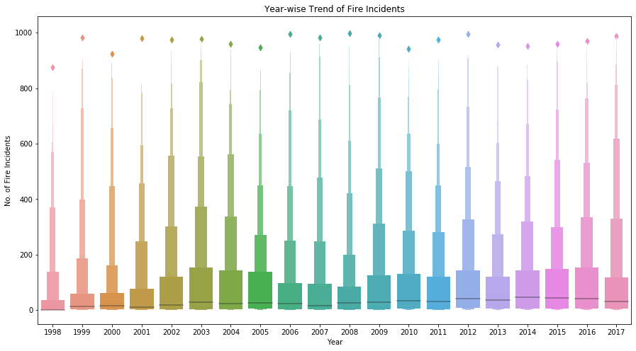

```python
# Monthly Variation of fires throughout the Years
plt.figure(figsize=(15,8))
sns.boxenplot(x='year', y='number', data=data)
plt.xlabel('Year')
plt.ylabel('No. of Fire Incidents')
plt.title('Year-wise Trend of Fire Incidents')
plt.show()
```

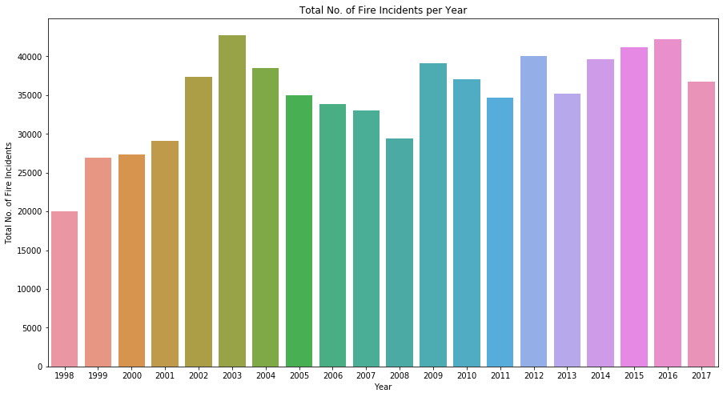

```python
# Total No. of Yearly Fire Incidents
pt_table = pd.pivot_table(data, values="number", index=["year"], aggfunc=np.sum)

x = np.array(pt_table.index)
y = np.array(pt_table.values).reshape(1,-1)[0]

# Plotting
plt.figure(figsize=(15,8))
sns.barplot(x, y)
plt.xlabel('Year')
plt.ylabel('Total No. of Fire Incidents')
plt.title('Total No. of Fire Incidents per Year')
plt.show()
```

###### Trends

- By looking at the Total/Average Number of Fire Incidents per Year, we can see the following Trends:
  - The Highest number of Fire Incidents occurred in the Year 2003, followed by 2016, 2015, and so on..
  - The Lowest number of Fire Incidents occurred in the Year 1998, followed by 1999, 2000, and so on..
  - Total Rate of Forest Fires increased approximately by a factor of 75%

## Modern Yearly Analysis

The graphs show a higher final count for fires compared to the first year in 1998, for the number of wildfires which occur in the Brazil. The data suprisingly doesn't have a perfect positive regression, but the total counts of incidents are increasing and it is more evident in a recent data mine conducted by the National Institue of Space Research (INPE) which released an infographic showing how many wildfires have become as a result of natural and human causes. The dataset we are using to extrapolate information about forest fires only covers until 2017, but the infographic is able to fill in the remaining data to make the data up to date to the current year we are interpreting the data. In the article, data journalist, Nial McCarthy, illustrates the significant increase in forest fires from January to August of 2019 compared to the previous year.

[figure not shown]

## Year Analysis

### Brazilian Fire Practices

The infographic above illustrates the increased rate of forest fires affecting the Brazilian part of the Amazon Basin. The article states that unsafe deforestation practices, carried out by the new Brazilian president, Jair Bolsonaro, and the dry arid environments has only increased the susceptibilty for the area to catch more violent and disastrous wildfires in response to multiple occurrences of fire suppression techniques. The negative side effect to the fire suppression techniques is that to efficiently and quickly get rid of the fire and prevent it from spreading, firefighters and units resort to using water and dry chemicals which ruin the land and slowly opens the same land to more problems in the future including inhabitability for animals and species but also the inability to use the land for resources including agriculture.

Source: Record Number Of Wildfires Burning In The Amazon:https://www.statista.com/chart/19089/number-of-wildfires-recorded-in-brazils-amazon-rainforest/

```python
# Uses the Brazilian Agriculture dataset and includes only the years 1998 to the present.
agriculture_data2 = agriculture_data[agriculture_data['Indicator Code'].isin(['EN.ATM.METH.AG.KT.CE'])]
agriculture_data2 = agriculture_data2[agriculture_data2['Year'] > 1997]
```

# Year Analysis

### CO2 Emissions Increase

As a result of these forest burnings, the environment is negatively impacted and thus logically will result in higher temperatures as a byproduct of the CO2 gas emissions from the burning wood. According to Dr. Werner Kurz from the NRC, forest fire CO2 emissions alone are released 2-3 more times the amount of fossil fuels byproducts. The negative effect of this is that the climate and environment will increase and make the land more difficult to reuse and later regrow. He continues to talk about how living trees are the reason why we aren't suffering from an overabundance of CO2 on Earth and burning the trees goes in the opposite direction by moving away from the long-term health of the planet.

Source: How do CO2 emissions from forest fires compare to those from fossil fuels?:https://www.cbc.ca/radio/quirks/sept-15-2018-summer-science-camping-under-a-volcano-plastic-in-beluga-bellies-and-more-1.4821942/how-do-co2-emissions-from-forest-fires-compare-to-those-from-fossil-fuels-1.4821944

[figure not shown]

```python
#Checks the total CO2 emissions from Brazil in each year
pt_table = agriculture_data2[['Country Name','Year','Value']].groupby(['Country Name','Year'], as_index=False).sum()
x = pt_table['Year']
y = pt_table['Value']
z = pt_table['Country Name']

# Plotting
plt.figure(figsize=(20,12))
sns.pointplot(x, y, hue = z, dodge=True)
plt.title('CO2 Emissions in Brazil from 1997 to 2008')
plt.xlabel('Year')
plt.ylabel('CO2 Emissions in Thousands of Metric Tons')
plt.show()
```

### Month-Wise Analysis

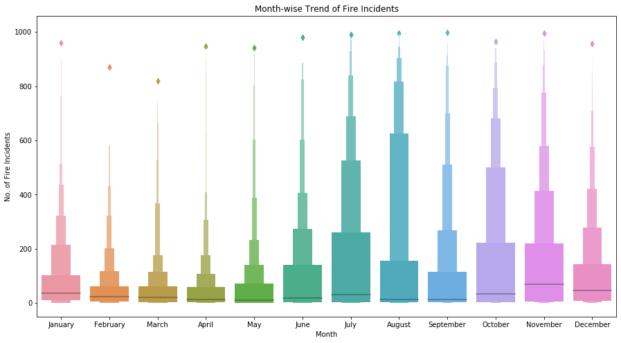

```python
# Monthly Variation of fires throughout the Years
plt.figure(figsize=(15,8))
sns.boxenplot(x='month', y='number', data=data)
plt.xlabel('Month')
plt.ylabel('No. of Fire Incidents')
plt.title('Month-wise Trend of Fire Incidents')
plt.show()
```

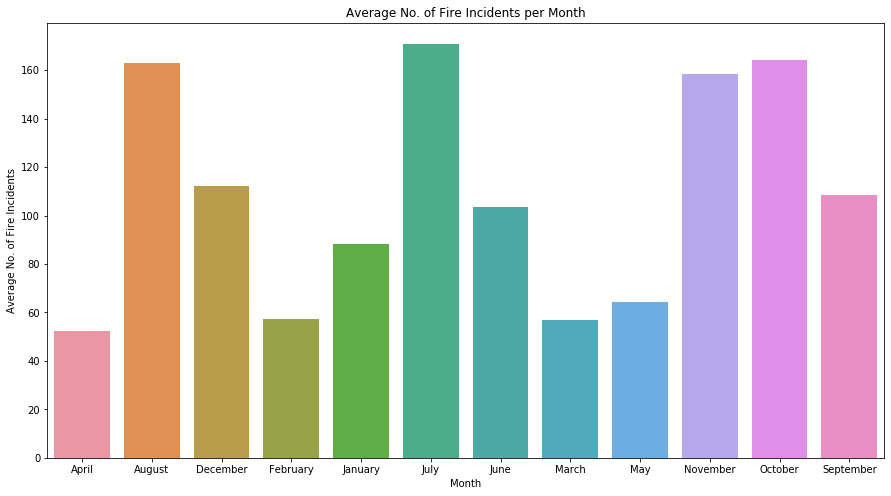

```python
# Average No. of Yearly Fire Incidents
pt_table = pd.pivot_table(data, values="number", index=["month"], aggfunc=np.mean)
x = np.array(pt_table.index)
y = np.array(pt_table.values).reshape(1,-1)[0]

# Plotting
plt.figure(figsize=(15,8))
sns.barplot(x, y)
plt.xlabel('Month')
plt.ylabel('Average No. of Fire Incidents')
plt.title('Average No. of Fire Incidents per Month')
plt.show()
```

###### Trends

- By looking at the Total/Average Number of Fire Incidents per Month, we can see the following Trends:
  - The Highest number of Fire Incidents occur in the Month of "July", followed by "October", "August", "November" and so on..
  - The Lowest number of Fire Incidents occur in the Month of "April", followed by "March", "February", "May" and so on..
- Most number of Fire Incidents Occur during the Second Half of the Year.

## Month Analysis

### Peak Fires and Surprising Twist

The data proves the first half of the year there is a significant drop in the average number of forest fires that occur. The data also indicates the summer months have a huge spike in the number of fire cases and the main reason is because forest fires are easier to occur in dry, arid temperatures. The Amazon's location is very unique. The location has been able to support so many different species in its vast biome, and still protect its natural habitats from the high tempreatures from being located near the equator. The relative distance from the Earth's midline has statistically proven to generally have higher temperatures compared to other places. This detail, along with the magnitude of the summer heat, makes the Brazilian part of the Amazon vulnerable to forest fire incidents.

The strange pattern near the end of the year, analyzed by Dr. Derek Arndt, Chief of the Monitoring Division at the National Centers for Environmental Information, says the sudden increase in the number of cases in October and November is understood to be caused by failure for fall showers to wet the land and settle the arid temperatures. When this is combined with the windy atmosphere, the land becomes even more dry.

Source Why Does California Have So Many Wildfires?:https://www.nytimes.com/2018/11/09/climate/why-california-fires.html

### State-wise Analysis

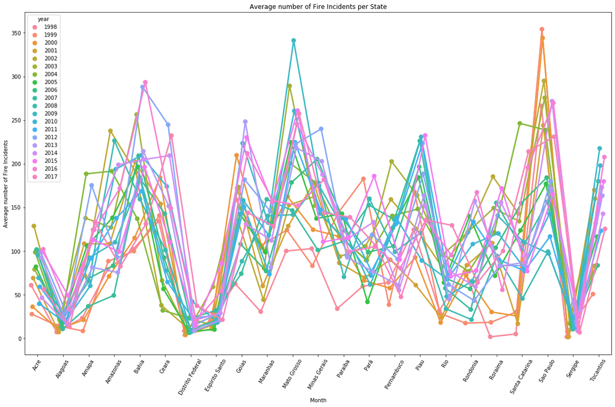

```python
# Average number of Fire Incidents per State, for each Year
pt_table = data[['year','state','number']].groupby(['year','state'], as_index=False).mean()
x = pt_table['state']
y = pt_table['number']
z = pt_table['year']

# Plotting
plt.figure(figsize=(20,12))
sns.pointplot(x, y, hue = z, dodge=True)
plt.title('Average number of Fire Incidents per State')
plt.xlabel('Month')
plt.xticks(rotation=60)
plt.ylabel('Average number of Fire Incidents')
plt.show()
```

###### Trends

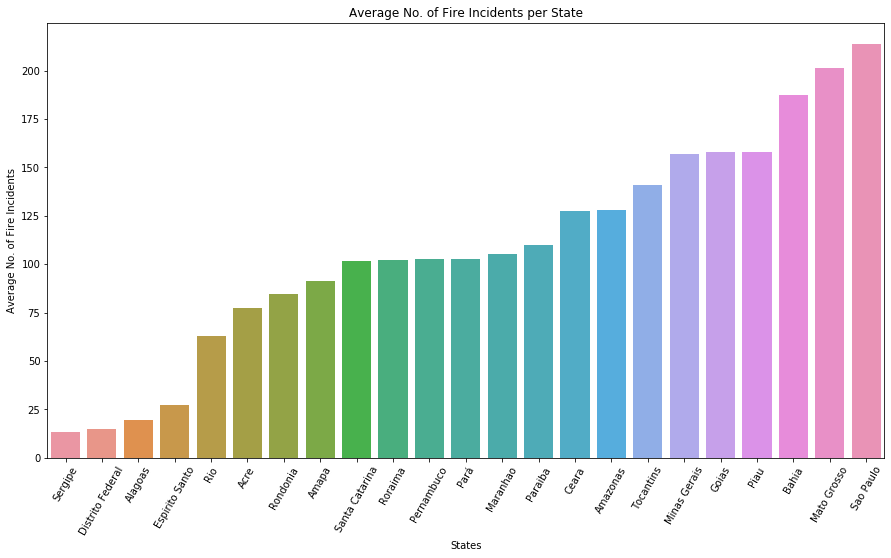

```python
# Average No. of Yearly Fire Incidents
pt_table = pd.pivot_table(data, values="number", index=["state"], aggfunc=np.mean)

x = np.array(pt_table.index)
y = np.array(pt_table.values).reshape(1,-1)[0]

# Plotting
plt.figure(figsize=(15,8))
sns.barplot(x, y, order=x[np.argsort(y)])
plt.xlabel('States')
plt.xticks(rotation=60)
plt.ylabel('Average No. of Fire Incidents')
plt.title('Average No. of Fire Incidents per State')
plt.show()
```

###### Trends

- By looking at the Average Number of Fire Incidents per Year, we can see the following Trends:
  - The Highest number of Fire Incidents occur in the State of "Sao Paulo", followed by "Mato Grosso", "Bahia", and so on..
  - The Lowest number of Fire Incidents occur in the State of "Sergipe", followed by "Distrito Federal", "Alagoass, and so on..
- In 19 years, the Highest number of Fire Incidents occur in the State of "Mato Grosso", a total of 96,246 times.

## State Analysis

### Analyzing the Extreme Cases

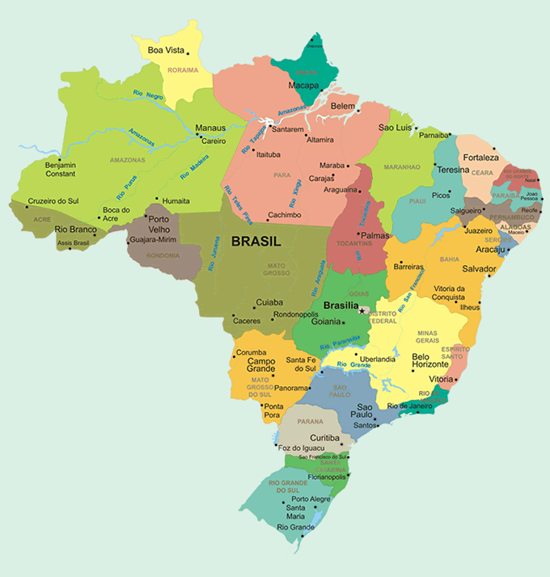

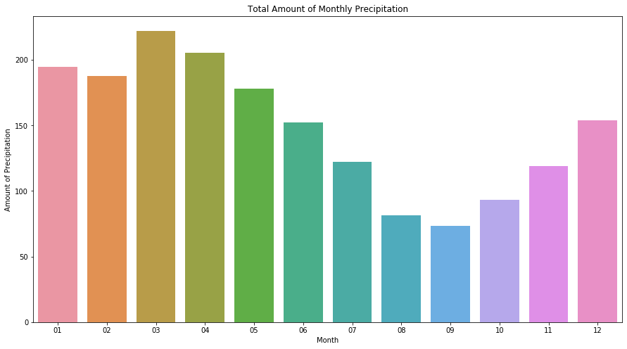

```python
# Total Amount of Yearly Precipitation
pt_table = pd.pivot_table(rainfall_data, values="precipitation", index=["Month"], aggfunc=np.mean)

x = np.array(pt_table.index)
y = np.array(pt_table.values).reshape(1,-1)[0]

# Plotting
plt.figure(figsize=(15,8))
sns.barplot(x, y)
plt.xlabel('Month')
plt.ylabel('Amount of Precipitation')
plt.title('Total Amount of Monthly Precipitation')
plt.show()
```

# Linear Regression

```python
#X,Y = make_regression(n_samples = 100, n_features=2, noise=0.1)
x = np.array(data['year']).reshape(-1,1)
y = data['number']
model = linear_model.LinearRegression()
model.fit(x,y)
coef = model.coef_
print('Regression Equation = ' + str(coef) + 'a + ' 'b')
print('R^2 Value = ' + str(model.score(x,y)))
```

```
Regression Equation = [2.16492433]a + b
R^2 Value = 0.004251116476173822
```

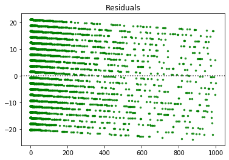

```python
predictions = model.predict(x)
plt3 = sns.residplot(y.values, predictions,color = "green",scatter_kws={'s':6} ).set_title("Residuals")
```

The graph is showing multiple trends because it doesn't follow any other datasets. Integrating local Brazil temperatures and other categories which were discussed earlier will allow for stricter predictions.